# CAPM, 자본자산 결정모형

연성

2021-12-05

## 개별 주식의 수익율 측정법

$$R_{i} = \alpha_{i} + \beta_{i}R_{m} + error$$
개별주식의 수익률은 위와 같은 모델로 표현할 수 있다.

[최소제곱법(Originary Least Square)](https://darkpgmr.tistory.com/56)에 의해 $\beta_{i}=\sigma_{im}/\sigma_{m}^2$ 으로 계산된다. 이를 해석하면 $\beta_{i}$ 는 시장과 개별주식의 공분산 / 시장의 분산이다. 이를 말로 풀어 설명하면 시장이 움직일 때 개별주식이 얼마나 민감하게 움직이는가다. 1일 경우 개별주식과 시장이 똑같이 움직이고 1보다 클 경우 시장보다 개별 주식이 더 많이 변동한다고 해석하면 된다.

## CAPM 비판

앞에서 살펴본 회귀분석을 적용하기 전에 [여러 가정](https://ko.wikipedia.org/wiki/%ED%9A%8C%EA%B7%80_%EB%B6%84%EC%84%9D)들을 만족해야한다. 여러 논문들에서 주식시장에서 여러 가정들이 만족하지 않음을 실험적으로 입증했지만 CAPM는 자본자산의 가격을 측정할 수 있는 지표로 아직까지 사용되고 있다. 따라서 개별 주식의 $\beta$ 값 분석을 본 글에서 해보고자 한다.

다만 OLS method에서는 이상값의 영향을 많이 받으므로 robust Least Trimmed Square (LTS) 방식과 MM추정법 (robust MM)을 이용해 $\beta$ 값도 추정하여 해석에 이용한다.

[robust MM](http://databaser.net/moniwiki/pds/_eb_a1_9c_eb_b2_84_ec_8a_a4_ed_8a_b8_ed_9a_8c_ea_b7_80_eb_b6_84_ec_84_9d/m_estimator.pdf)와 LTS에서 구한 $\beta$ 값도 LS방식을 이용해 구한 $\beta$값과 동일하게 해석할 수 있다.

본고에서는 52주(1년) 종가 데이터를 이용한다.

## 기본설정

```r
library(tidyverse)
library(tqk)
library(quantmod)
library(httr)
library(dplyr)
library(rvest)
library(MASS)
library(lubridate)
```

[tqk 출처](https://github.com/mrchypark/tqk)

```r
OneYearAgo = Sys.Date() - 365
```

## 데이터

### 코스피 데이터

```r
data = list()

tryCatch({

  for(j in 1:60)
  {
    url = paste0('https://finance.naver.com/sise/sise_index_day.nhn?code=KOSPI&page=',j)
    down_table = GET(url)
    Sys.setlocale("LC_ALL", "English")
    table = read_html(down_table, encoding = "EUC-KR")%>%html_table(fill = TRUE)
    mytable = table[[1]]
    Sys.setlocale("LC_ALL", "Korean")
    mytable = na.omit(mytable)
    rownames(mytable) = NULL
    data[[j]] = mytable
    Sys.sleep(0.01)
  }

}, error = function(e) {
  warning(paste0("Error"))

})

data2 = do.call(rbind, data)

KS11 = data2[order(data2$날짜),][,1:2]

KS11 = data.frame(KS11)

KS11$체결가 = lapply( KS11$체결가, function(x) as.numeric(gsub("[+-,]", "", x)))

KS11$체결가 = unlist(KS11$체결가)

kospi = KS11
kospi$날짜= ymd(kospi[, 1])

kospi = kospi %>% filter(날짜 > OneYearAgo)
kospi$return = kospi$체결가 / lag(kospi$체결가) -1
kospi = na.omit(kospi)

head(kospi)
```

```
##         날짜  체결가       return
## 2 2020-12-08 2700.93 -0.016212338
## 3 2020-12-09 2755.47  0.020193045
## 4 2020-12-10 2746.46 -0.003269860
## 5 2020-12-11 2770.06  0.008592880
## 6 2020-12-14 2762.20 -0.002837484
## 7 2020-12-15 2756.82 -0.001947723
```

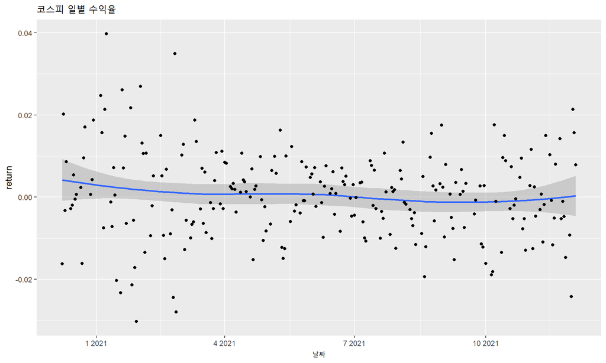

```r
ggplot(kospi, aes(x=날짜, y = return)) +
        geom_smooth() +
        geom_point() +
        ggtitle("코스피 일별 수익율")
```

### 삼성전자 데이터

```r
code_get() %>%
  filter(grepl("^삼성전자$", name)) %>%
  dplyr::select(code) %>%
  tqk_get(from = OneYearAgo) -> samsung

samsung$return = (samsung$close)/lag(samsung$close) - 1
samsung = na.omit(samsung)
head(samsung)
```

```
## # A tibble: 6 x 8
##   date        open  high   low close   volume adjusted   return
##   <date>     <dbl> <dbl> <dbl> <dbl>    <int>    <dbl>    <dbl>
## 1 2020-12-08 72200 72900 71600 71700 25000338    71700 -0.0165
## 2 2020-12-09 72100 73900 72000 73900 24077996    73900  0.0307
## 3 2020-12-10 72700 73800 72500 72900 39882928    72900 -0.0135
## 4 2020-12-11 73500 73800 73100 73400 18486672    73400  0.00686
## 5 2020-12-14 73600 74500 73200 73800 21510415    73800  0.00545
## 6 2020-12-15 73800 74100 73300 73800 20863671    73800  0
```

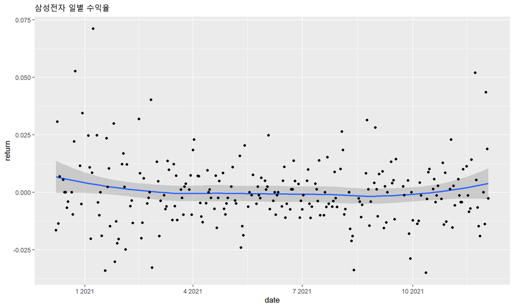

```r
ggplot(samsung, aes(x=date, y = return)) +
        geom_smooth() +
        geom_point() +
        ggtitle("삼성전자 일별 수익율")
```

### 삼성전자와 코스피 수익율

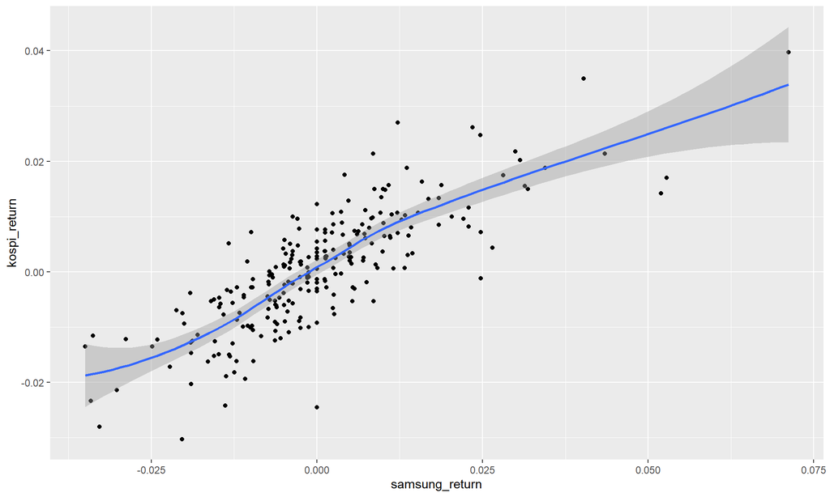

```r
kospi_samsung_return = data.frame(cbind(kospi$return,samsung$return))

colnames(kospi_samsung_return) = c("kospi_return", "samsung_return")

ggplot(data = kospi_samsung_return, aes(x=samsung_return, y = kospi_return)) +
        geom_point() +
        geom_smooth()
```

## 회귀분석

### OLS 회귀분석

```r
OLS_model = lm(samsung_return~kospi_return, data = kospi_samsung_return)

OLS_model
```

```
##
## Call:
## lm(formula = samsung_return ~ kospi_return, data = kospi_samsung_return)
##
## Coefficients:
##  (Intercept)  kospi_return
##   -0.0001596     1.0991760
```

OLS로 추정한 $\beta$ 값이 1.0991760 으로 삼성전자와 코스피 시장을 비슷하게 움직이는 모습을 확인 할 수 있다.

### LTS 회귀분석

```r
LTS_model = lqs(samsung_return~kospi_return, data = kospi_samsung_return, method = 'lqs')

LTS_model
```

```
## Call:
## lqs.formula(formula = samsung_return ~ kospi_return, data = kospi_samsung_return,
##     method = "lqs")
##
## Coefficients:
##  (Intercept)  kospi_return
##    -0.001752      0.678347
##
## Scale estimates 0.006508 0.006395
```

### robust MM 회귀분석

```r
MM_model = rlm(samsung_return~kospi_return, data = kospi_samsung_return)

MM_model
```

```
## Call:
## rlm(formula = samsung_return ~ kospi_return, data = kospi_samsung_return)
## Converged in 7 iterations
##
## Coefficients:
##   (Intercept)  kospi_return
## -0.0005982284  1.0303685837
##
## Degrees of freedom: 245 total; 243 residual
## Scale estimate: 0.00741
```

## 해석

OLS,robust MM 을 이용한 추정에서는 $\beta$ 값 1과 유사하게 나왔다 이는 삼성전자는 코스피와 비슷하게 움직인다고 해석할 수 있다.

LTS가 이상치로 추정되는 값을 제외하고 계산한다는 점을 미뤄볼 때 삼성전자와 코스피는 주식시장에 대형사건(ex.코로나19)이 있을 경우 비슷한 움직임을 보이고 큰 사건이 없은 경우 삼성전자는 코스피가 움직이는 것보다 덜 민감하게 움직인다고 해석 할 수 있다.